# PS5: markdown, basic plots

Tianze Xu

2023-02-17

```r
# load libraries
library(dplyr)
library(ggplot2)
```

## 1) Load and check data (5pt)

### You first task is to do a very simple data check:

### 1.1) (1pt) For solving the problems, and answering the questions, create a new rmarkdown document with an appropriate title. See https://faculty.washington.edu/otoomet/info201-book/r-markdown.html#r-markdown-rstudio-creating.

### 1.2) (2pt) Load data. How many rows/columns do we have?

```r
df <- read.csv('../data/gapminder.csv.bz2', sep = '\t')
nrow(df)
```

```
## [1] 13055
```

```r
ncol(df)
```

```
## [1] 25
```

There are 13055 rows and 25 columns.

### 1.3) (2pt) Print a small sample of data. Does it look OK?

```r
sample_n(df, 5)
```

```
##   iso3                 name iso2   region                      sub.region
## 1  GRD              Grenada   GD Americas Latin America and the Caribbean
## 2  AIA             Anguilla   AI Americas Latin America and the Caribbean
## 3  MLI                 Mali   ML   Africa              Sub-Saharan Africa
## 4  ROU              Romania   RO   Europe                  Eastern Europe
## 5  ARE United Arab Emirates   AE     Asia                    Western Asia
##   intermediate.region time totalPopulation fertilityRate lifeExpectancy
## 1           Caribbean 1997          101567         2.870       71.96400
## 2           Caribbean   NA              NA            NA             NA
## 3      Western Africa 1964         5503752         7.030       29.09700
## 4                     2011        20147528         1.470       74.40976
## 5                     1966          159976         6.817       57.48200
##   childMortality youthFemaleLiteracy youthMaleLiteracy adultLiteracy   GDP_PC
## 1           16.5                  NA                NA            NA 5078.163
## 2             NA                  NA                NA            NA       NA
## 3          413.5                  NA                NA            NA       NA
## 4           11.8            98.97622          99.01409      98.60429 8411.917
## 5          138.4                  NA                NA            NA       NA
##   accessElectricity agriculturalLand agricultureTractors cerealProduction
## 1                NA              110                  12              300
## 2                NA               NA                  NA               NA
## 3                NA           317130                 200           947700
## 4               100           139820                  NA         20842160
## 5                NA             2100                 132               NA
##   fertilizerHa       co2 greenhouseGases  co2_PC pm2.5_35 battleDeaths
## 1           NA   168.682        208.0097 1.66080       NA           NA
## 2           NA        NA              NA      NA       NA           NA
## 3      0.18149   176.016              NA 0.03198       NA           NA
## 4     54.13496 85268.751     126194.4156 4.23222        0           NA
## 5           NA    25.669              NA 0.16046       NA           NA
```

Yes, the data looks okay.

## 2) Descriptive statistics (15pt)

### 2.1) (3pt) How many countries are there in the dataset? Analyze all three: iso3, iso2 and name

```r
n_distinct(df$iso3)
```

```
## [1] 253
```

```r
n_distinct(df$iso2)
```

```
## [1] 249
```

```r
n_distinct(df$name)
```

```
## [1] 250
```

There are 253 unique iso3 (3-letter country code), 249 unique iso2 (2-letter country code), and 250 unique country names.

### 2.2) If you did this correctly, you saw that there are more iso-2 codes than names, and there are even more iso3 -codes. What is going on? Can you find it out?

#### 2.2.a) (5pt) Find how many names are there for each iso-2 code. Are there any iso-2 codes that correspond to more than one name? What are these countries?

```r
df %>% group_by(iso2) %>%
  summarise(name_count=n_distinct(name)) %>%
  arrange(desc(name_count))
```

```
## # A tibble: 249 x 2
##    iso2  name_count
##    <chr>      <int>
##  1 ""             2
##  2 "AD"           1
##  3 "AE"           1
##  4 "AF"           1
##  5 "AG"           1
##  6 "AI"           1
##  7 "AL"           1
##  8 "AM"           1
##  9 "AO"           1
## 10 "AQ"           1
## # ... with 239 more rows
```

```r
df %>% filter(iso2=='') %>% select(iso3, iso2, name) %>% distinct()
```

```
##          iso3 iso2    name
## 1     CHANISL
## 2         GBM
## 3         KOS
## 4         NAM      Namibia
## 5 NLD_CURACAO
```

#### 2.2.b) (5pt) Now repeat the same for name and iso3-code. Are there country names that have more than one iso3-code? What are these countries? Hint: two of these entitites are CHANISL and NLD CURACAO.

```r
df %>% group_by(name) %>%
  summarise(iso3_count=n_distinct(iso3)) %>%
  arrange(desc(iso3_count))
```

```
## # A tibble: 250 x 2
##    name                  iso3_count
##    <chr>                      <int>
##  1 ""                             4
##  2 "Afghanistan"                  1
##  3 "Albania"                      1
##  4 "Algeria"                      1
##  5 "American Samoa"               1
##  6 "Andorra"                      1
##  7 "Angola"                       1
##  8 "Anguilla"                     1
##  9 "Antarctica"                   1
## 10 "Antigua and Barbuda"          1
## # ... with 240 more rows
```

```r
df %>% filter(name=='') %>% select(iso3, iso2, name) %>% distinct()
```

```
##          iso3 iso2 name
## 1     CHANISL
## 2         GBM
## 3         KOS
## 4 NLD_CURACAO
```

There are 4 countries that have iso3-code, but without names. These countries are CHANISL, GBM, KOS, and NLD_CURACAO.

### 2.3) (2pt) What is the minimum and maximum year in these data?

```r
df %>% filter(!is.na(time)) %>%
  summarise(min = min(time),
            max = max(time))
```

```
##    min  max
## 1 1960 2019
```

## 3) CO2 emissions (30pt)

### Next, let’s analyze CO2 emissions.

### 3.1) (2pt) How many missing co2 emissions are there for each year? Analyze both missing CO2 and co2_PC. Which years have most missing data?

```r
df %>% group_by(time) %>%
  summarise(co2_na_count = sum(is.na(co2) | is.na(co2_PC))) %>%
  arrange(desc(co2_na_count))
```

```
## # A tibble: 61 x 2
##     time co2_na_count
##    <int>        <int>
##  1  2017          217
##  2  2018          217
##  3  2019          217
##  4  1960           60
##  5  1961           60
##  6  1962           58
##  7  1963           57
##  8  1964           51
##  9  1965           51
## 10  1966           51
## # ... with 51 more rows
```

Year 2017, 2018, and 2019 have the most missing CO2 data.

### 3.2) (5pt) Make a plot of total CO2 emissions over time for the U.S, China, and India. Add a few more countries of your choice. Explain what do you see.

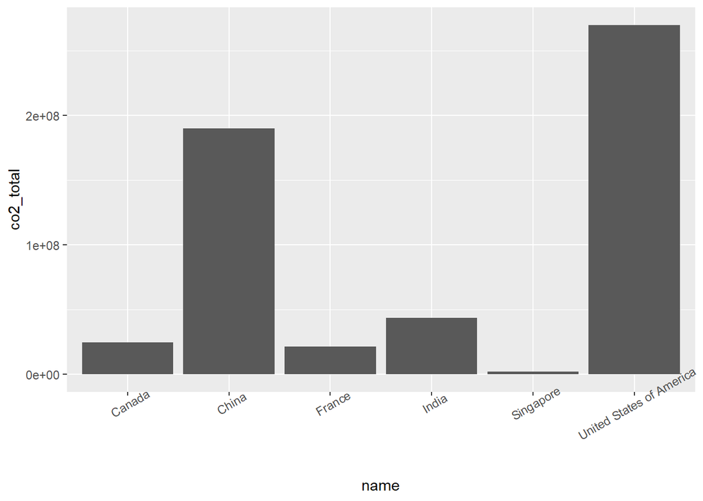

```r
# calculate co2 numbers by country
df_co2 <- df %>% filter(iso2 %in% c('US', 'CN', 'IN', 'SG', 'FR', 'CA') & !is.na(co2)) %>%
            group_by(name) %>%
            summarise(co2_total=sum(co2))

# bar plot using ggplot library
ggplot(data=df_co2, aes(x=name, y=co2_total)) +
  geom_bar(stat="identity") +
  theme(axis.text.x = element_text(angle = 30))
```

From the above bar chart, we see US has the highest total CO2 emissions. China has the 2nd highest CO2 emissions. Singapore has the lowest CO2 emissions.

### 3.3) (5pt) Now let’s analyze the CO2 emissions per capita (co2_PC). Make a similar plot of the same countries. What does this figure suggest?

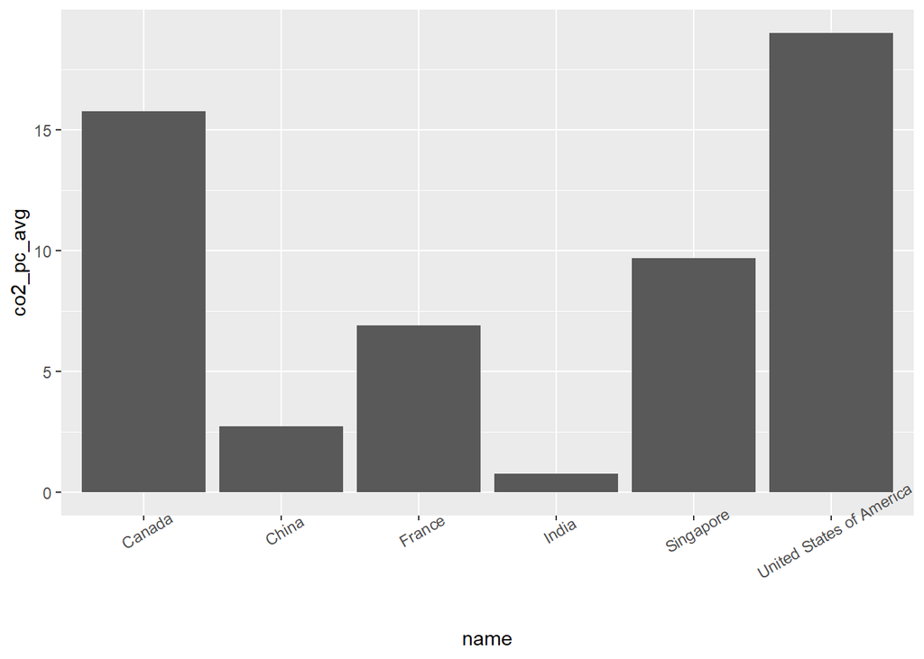

```r
# calculate co2 numbers by country
df_co2_pc <- df %>% filter(iso2 %in% c('US', 'CN', 'IN', 'SG', 'FR', 'CA') & !is.na(co2_PC)) %>%
            group_by(name) %>%
            summarise(co2_pc_avg=mean(co2_PC))

# bar plot using ggplot library
ggplot(data=df_co2_pc, aes(x=name, y=co2_pc_avg)) +
  geom_bar(stat="identity") +
  theme(axis.text.x = element_text(angle = 30))
```

The above figure suggests that US still has the highest CO2 emissions per capita, while India has the lowest CO2 emissions per capita.

### 3.4) (6pt) Compute average CO2 emissions per capita across the continents (assume region is the same as continent). Comment what do you see.

### Note: just compute averages over countries and ignore the fact that countries are of different size.

### Hint: Americas 2016 should be 4.80.

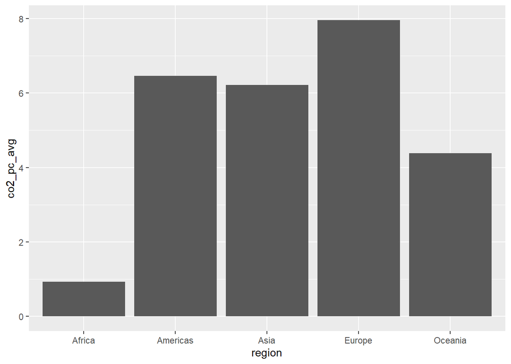

```r
# calculate co2 numbers by region
df_co2_pc_region <- df %>% filter(region!='' & !is.na(co2_PC)) %>%
                      group_by(region) %>%
                      summarise(co2_pc_avg=mean(co2_PC))

ggplot(data=df_co2_pc_region, aes(x=region, y=co2_pc_avg)) +
  geom_bar(stat="identity")
```

From the above plot, we see Europe is the continent that has the highest CO2 emissions per capita, while Africa has the lowest.

### 3.5) (7pt) Make a barplot where you show the previous results–average CO2 emissions per capita across continents in 1960 and 2016.

### Hint: it should look something along these lines:

```r
df_co2_pc_region_year <- df %>% filter(region!='' & !is.na(co2_PC) & time %in% c(1960, 2016)) %>%
                      group_by(region, time) %>%
                      summarise(co2_pc_avg=mean(co2_PC))
```

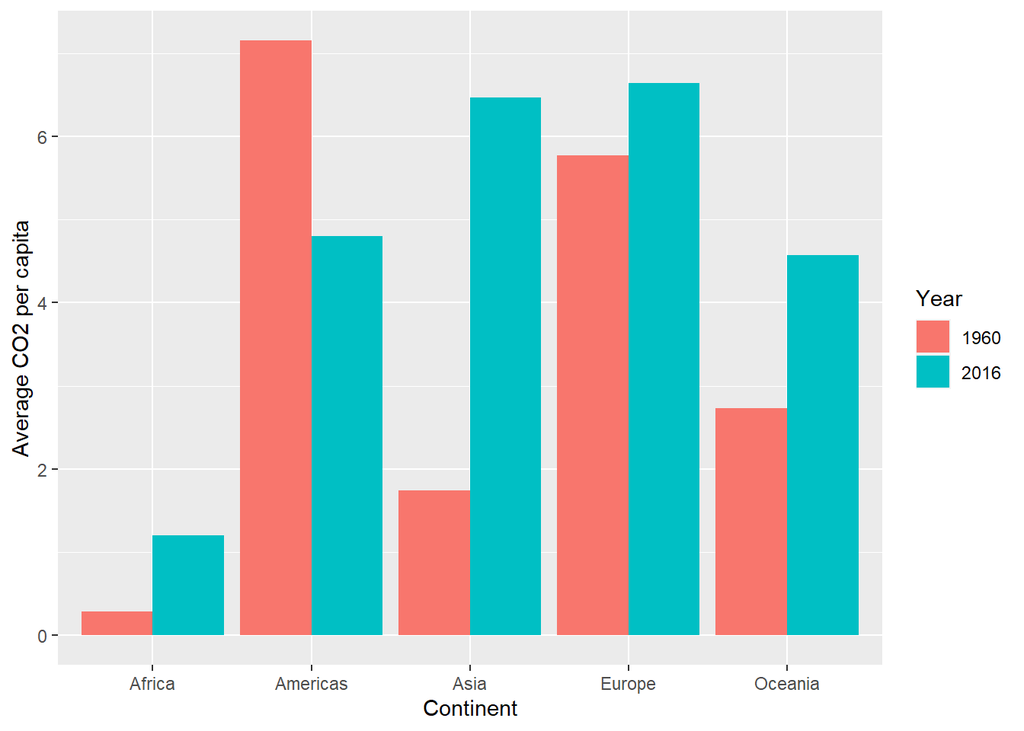

```r
df_co2_pc_region_year$Year <- as.factor(df_co2_pc_region_year$time)

ggplot(data=df_co2_pc_region_year, aes(x=region, y=co2_pc_avg, fill=Year)) +
  geom_bar(position = "dodge", stat="identity") +
  labs(x='Continent', y='Average CO2 per capita')
```

### 3.6) Which countries are the three largest, and three smallest CO2 emitters (in terms of CO2 per capita) in 2019 for each continent? (Assume region is continent)

```r
df %>% filter(time==2019 & !is.na(co2_PC))
```

```
##  [1] iso3                name                iso2
##  [4] region              sub.region          intermediate.region
##  [7] time                totalPopulation     fertilityRate
## [10] lifeExpectancy      childMortality      youthFemaleLiteracy
## [13] youthMaleLiteracy   adultLiteracy       GDP_PC
## [16] accessElectricity   agriculturalLand    agricultureTractors
## [19] cerealProduction    fertilizerHa        co2
## [22] greenhouseGases     co2_PC              pm2.5_35
## [25] battleDeaths
## <0 rows> (or 0-length row.names)
```

Since all the co2_PC values in year 2019 are missing, we are not able to find the answer using this dataset.

## 4) GDP per capita (50pt)

### Let’s look at GDP per capita (GDP_PC).

### 4.1) (8pt) Make a scatterplot of GDP per capita versus life expectancy by country, using data for 1960. Make the point size dependent on the country size, and color those according to the continent. Feel free to adjust the plot in other ways to make it better.

### Comment what do you see there.

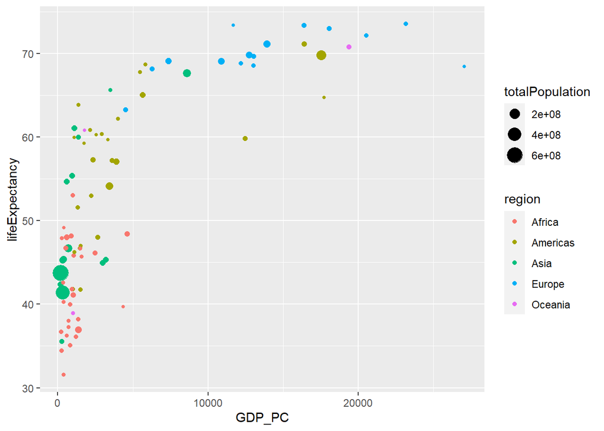

```r
df_1960 <- df %>% filter(time==1960 & !is.na(name) & !is.na(GDP_PC) & !is.na(lifeExpectancy))

ggplot(df_1960, aes(x=GDP_PC, y=lifeExpectancy)) +
  geom_point(aes(size=totalPopulation, color=region))
```

- I see some Asian countries with green color that have large population, low GDP per capita, and low life expectancy.
- Many African countries with red color have low GDP per capita and low life expectancy.
- Many Europe countries with blue color have high GDP per capita and high life expectancy.

### 4.2) (4pt) Make a similar plot, but this time use 2019 data only.

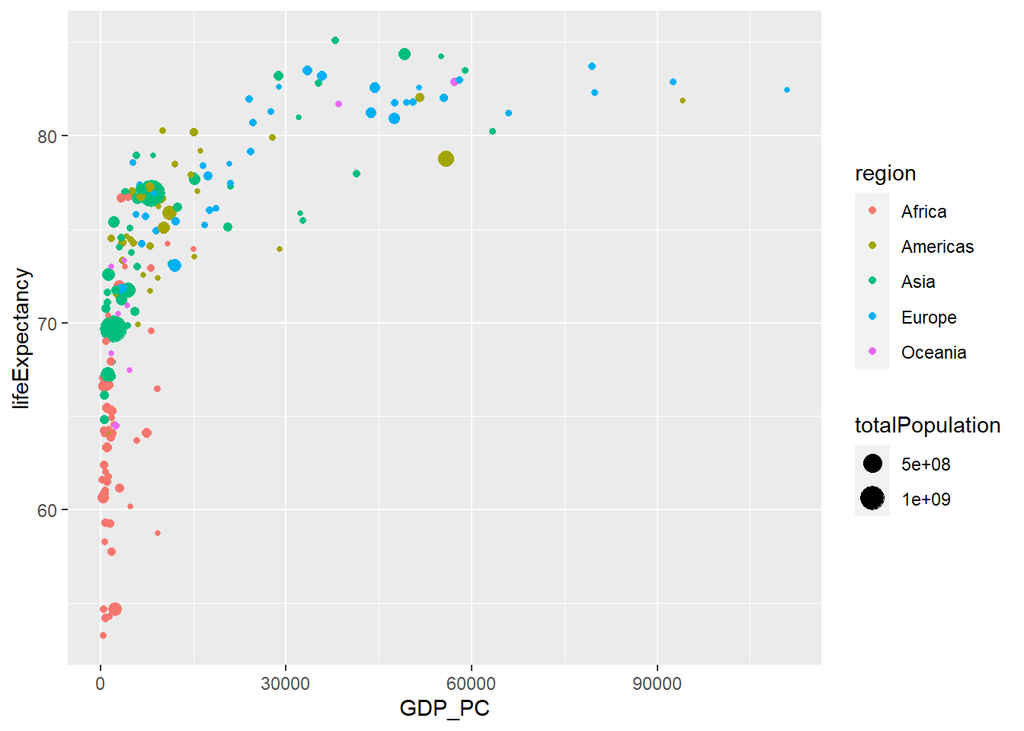

```r
df_2019 <- df %>% filter(time==2019 & !is.na(name) & !is.na(GDP_PC) & !is.na(lifeExpectancy) & region!='')

ggplot(df_2019, aes(x=GDP_PC, y=lifeExpectancy)) +
  geom_point(aes(size=totalPopulation, color=region))
```

### 4.3) (6pt) Compare these two plots and comment what do you see. How has world developed through the last 60 years?

- During the last 60 years, many Asian countries have greater GDP per capita and larger life expectancy.
- Some African countries still have low GDP per capita, but they have larger life expectancy in 2019.
- American, European, and Oceanian countries did not show drastic change according to the plots.

### 4.4) (6pt) Compute the average life expectancy for each continent in 1960 and 2019. Do the results fit with what do you see on the figures?

### Note: here as average I mean just average over countries, ignore the fact that countries are of different size.

```r
df %>% filter(time %in% c(1960,2019) & !is.na(name) & !is.na(GDP_PC) & !is.na(lifeExpectancy) & region!='') %>%
  group_by(region, time) %>%
  summarise(avg_lE = mean(lifeExpectancy))
```

```
## # A tibble: 10 x 3
## # Groups:   region [5]
##    region    time avg_lE
##    <chr>    <int>  <dbl>
##  1 Africa    1960   41.9
##  2 Africa    2019   64.3
##  3 Americas  1960   57.6
##  4 Americas  2019   75.6
##  5 Asia      1960   50.4
##  6 Asia      2019   74.8
##  7 Europe    1960   70.1
##  8 Europe    2019   79.2
##  9 Oceania   1960   56.9
## 10 Oceania   2019   72.5
```

### 4.5) (8pt) Compute the average LE growth from 1960-2019 across the continents. Show the results in the order of growth. Explain what do you see.

### Hint: these data (data in long form) is not the simplest to compute growth. But you may want to check out the lag() function. And do not forget to group data by continent when using lag(), otherwise your results will be messed up! See https://faculty.washington.edu/otoomet/info201-book/dplyr.html#dplyr-helpers-compute.

```r
df %>% filter(time %in% c(1960,2019) & !is.na(name) & !is.na(GDP_PC) & !is.na(lifeExpectancy) & region!='') %>%
  group_by(region, time) %>%
  summarise(avg_lE = mean(lifeExpectancy)) %>%
  mutate(lag1_LE = lag(avg_lE, n=1, order_by=time)) %>%
  filter(time==2019) %>%
  summarise(LE_growth = avg_lE - lag1_LE) %>%
  arrange(desc(LE_growth))
```

```
## # A tibble: 5 x 2
##   region   LE_growth
##   <chr>        <dbl>
## 1 Asia         24.5
## 2 Africa       22.4
## 3 Americas     18.0
## 4 Oceania      15.7
## 5 Europe        9.06
```

From the above table, we can find Asia and Africa is the top2 contitents by life expectancy growth, while Europe has the least life expectancy growth.

### 4.6) (6pt) Show the histogram of GDP per capita for years of 1960 and 2019. Try to put both histograms on the same graph, see how well you can do it!

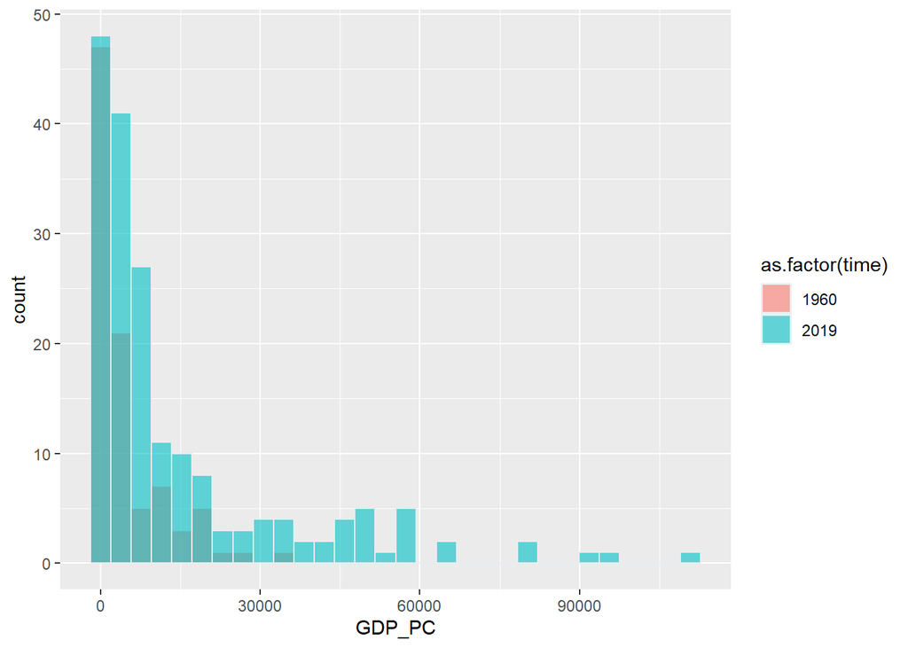

```r
data <- df %>% filter(time %in% c(1960,2019) & !is.na(GDP_PC))

ggplot(data, aes(GDP_PC, fill=as.factor(time))) +
   geom_histogram(color='#e9ecef', alpha=0.6, position='identity')
```

### 4.7) (6pt) What was the ranking of US in terms of life expectancy in 1960 and in 2019? (When counting from top.)

### Hint: check out the function rank()!

### Hint2: 17 for 1960.

```r
# for year 1960
df_le_1960 <- df %>% filter(time==1960 & name!='')
df_le_1960$Rank <- rank(-df_le_1960$lifeExpectancy, ties.method = 'first')
us_1960 <- df_le_1960 %>% filter(iso2=='US') %>% select(name, time, Rank)
us_1960
```

```
##                       name time Rank
## 1 United States of America 1960   17
```

```r
# for year 2019
df_le2 <- df %>% filter(time==2019 & name!='')
df_le2$Rank <- rank(-df_le2$lifeExpectancy, ties.method = 'first')
us_2019 <- df_le2 %>% filter(iso2=='US') %>% select(name, time, Rank)
us_2019
```

```
##                       name time Rank
## 1 United States of America 2019   46
```

### 4.8) (6pt) If you did this correctly, then you noticed that US ranking has been falling quite a bit. But we also have more countries in 2019–what about the relative rank divided by the corresponding number of countries that have LE data in the corresponding year?

### Hint: 0.0802 for 1960.

```r
# for year 1960
us_1960$relative_rank <- us_1960$Rank / n_distinct(df_le_1960$name)
us_1960
```

```
##                       name time Rank relative_rank
## 1 United States of America 1960   17    0.08018868
```

```r
# for year 2019
us_2019$relative_rank <- us_2019$Rank / n_distinct(df_le2$name)
us_2019
```

```
##                       name time Rank relative_rank
## 1 United States of America 2019   46     0.2159624
```

The relative rank of US also falls from 0.0802 to 0.2160, since year 1960 to 2019.

**Finally**, I spent 8 hours on this PS.